# Modeling in R

Ben Bellman  
August 28, 2018

### The stats package

- `stats` is one of the eight base packages
- Huge list of models, statistics, tests, distributions, etc.
  - [Full list for R version 3.5.1](https://www.rdocumentation.org/packages/stats/versions/3.5.1)
- Lots of packages are devoted to implementing specific models
- Range of available methods is a major strength of R
- However, much less support compared to Stata, no warranty!

### Setting up the data

```r
library(tidyverse)
library(here)

salaries <- read_csv(here("data","white-house-salaries.csv")) %>%
  rename(name = employee_name) %>%
  group_by(name) %>%
  mutate(tenure = rank(year) - 1,   # make intercept interpretable to first year
         gender = factor(gender),
         term = factor(term),
         year = year - 2001)   # make intercept interpretable to 2001
```

### OLS Models

- Estaimte OLS regression models with `lm()`
- You'll need to center/scale variables yourself

```r
ols_1 <- lm(salary ~ tenure + year + term + gender, data = salaries)

summary(ols_1)
```

```
Call:
lm(formula = salary ~ tenure + year + term + gender, data = salaries)

Residuals:
   Min     1Q Median     3Q    Max
-94355 -29009 -13198  24863 137614

Coefficients:
            Estimate Std. Error t value Pr(>|t|)
(Intercept)  54982.4     1088.9  50.494  < 2e-16 ***
tenure        2222.7      224.6   9.896  < 2e-16 ***
year          1742.3      101.8  17.112  < 2e-16 ***
termsecond   -4979.9      929.8  -5.356 8.79e-08 ***
gendermale   11495.9      907.6  12.667  < 2e-16 ***
---
Signif. codes:  0 '***' 0.001 '**' 0.01 '*' 0.05 '.' 0.1 ' ' 1

Residual standard error: 38230 on 7103 degrees of freedom
Multiple R-squared:  0.08555,   Adjusted R-squared:  0.08504
F-statistic: 166.1 on 4 and 7103 DF,  p-value: < 2.2e-16
```

### OLS Models

- `anova()` provides analysis of variance across model specifications

```r
ols_2 <- lm(salary ~ tenure + year + term, data = salaries)

anova(ols_1, ols_2)
```

```
Analysis of Variance Table

Model 1: salary ~ tenure + year + term + gender
Model 2: salary ~ tenure + year + term
  Res.Df        RSS Df   Sum of Sq      F    Pr(>F)
1   7103 1.0380e+13
2   7104 1.0615e+13 -1 -2.3448e+11 160.45 < 2.2e-16 ***
---
Signif. codes:  0 '***' 0.001 '**' 0.01 '*' 0.05 '.' 0.1 ' ' 1
```

### Diagnostic plots

- The `ggfortify()` package provide a simple function for diagnostic plots

```r
library(ggfortify)
autoplot(ols_1)
```

### Diagnostic plots

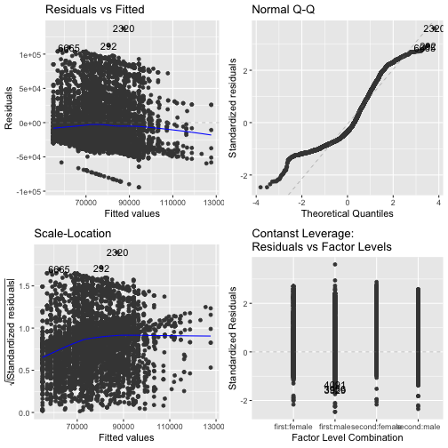

### The broom package

- Most model functions output lists with lots of different data types and results
  - Hard to work with these custom classes
- `broom` package converts model results into a tidy data frame
  - Useful for analysis and visualizing
- Two main functions: `tidy()` and `augment()`
  - `tidy()` describes the model and coefficients
  - `augment()` collects observation-level attributes

### The broom package

- Let's look at the `lm()` output

```r
str(ols_1)
```

```
List of 13
 $ coefficients : Named num [1:5] 54982 2223 1742 -4980 11496
  ..- attr(*, "names")= chr [1:5] "(Intercept)" "tenure" "year" "termsecond" ...
 $ residuals    : Named num [1:7108] -40417 -15417 -44417 11583 -28343 ...
  ..- attr(*, "names")= chr [1:7108] "1" "2" "3" "4" ...
 $ effects      : Named num [1:7108] -6442223 520137 -647660 -215921 484232 ...
  ..- attr(*, "names")= chr [1:7108] "(Intercept)" "tenure" "year" "termsecond" ...
 $ rank         : int 5
 $ fitted.values: Named num [1:7108] 80417 80417 80417 80417 71143 ...
  ..- attr(*, "names")= chr [1:7108] "1" "2" "3" "4" ...
 $ assign       : int [1:5] 0 1 2 3 4
 $ qr           :List of 5
  ..$ qr   : num [1:7108, 1:5] -84.309 0.0119 0.0119 0.0119 0.0119 ...
  .. ..- attr(*, "dimnames")=List of 2
  .. .. ..$ : chr [1:7108] "1" "2" "3" "4" ...
  .. .. ..$ : chr [1:5] "(Intercept)" "tenure" "year" "termsecond" ...
  .. ..- attr(*, "assign")= int [1:5] 0 1 2 3 4
  .. ..- attr(*, "contrasts")=List of 2
  .. .. ..$ term  : chr "contr.treatment"
  .. .. ..$ gender: chr "contr.treatment"
  ..$ qraux: num [1:5] 1.01 1.01 1 1.01 1.01
  ..$ pivot: int [1:5] 1 2 3 4 5
  ..$ tol  : num 1e-07
  ..$ rank : int 5
  ..- attr(*, "class")= chr "qr"
 $ df.residual  : int 7103
 $ contrasts    :List of 2
  ..$ term  : chr "contr.treatment"
  ..$ gender: chr "contr.treatment"
 $ xlevels      :List of 2
  ..$ term  : chr [1:2] "first" "second"
  ..$ gender: chr [1:2] "female" "male"
 $ call         : language lm(formula = salary ~ tenure + year + term + gender, data = salaries)
 $ terms        :Classes 'terms', 'formula'  language salary ~ tenure + year + term + gender
  .. ..- attr(*, "variables")= language list(salary, tenure, year, term, gender)
  .. ..- attr(*, "factors")= int [1:5, 1:4] 0 1 0 0 0 0 0 1 0 0 ...
  .. .. ..- attr(*, "dimnames")=List of 2
  .. .. .. ..$ : chr [1:5] "salary" "tenure" "year" "term" ...
  .. .. .. ..$ : chr [1:4] "tenure" "year" "term" "gender"
  .. ..- attr(*, "term.labels")= chr [1:4] "tenure" "year" "term" "gender"
```

[output cut: 13 more lines]

```
  ..- attr(*, "terms")=Classes 'terms', 'formula'  language salary ~ tenure + year + term + gender
  .. .. ..- attr(*, "variables")= language list(salary, tenure, year, term, gender)
  .. .. ..- attr(*, "factors")= int [1:5, 1:4] 0 1 0 0 0 0 0 1 0 0 ...
  .. .. .. ..- attr(*, "dimnames")=List of 2
  .. .. .. .. ..$ : chr [1:5] "salary" "tenure" "year" "term" ...
  .. .. .. .. ..$ : chr [1:4] "tenure" "year" "term" "gender"
  .. .. ..- attr(*, "term.labels")= chr [1:4] "tenure" "year" "term" "gender"
  .. .. ..- attr(*, "order")= int [1:4] 1 1 1 1
  .. .. ..- attr(*, "intercept")= int 1
  .. .. ..- attr(*, "response")= int 1
  .. .. ..- attr(*, ".Environment")=<environment: R_GlobalEnv>
  .. .. ..- attr(*, "predvars")= language list(salary, tenure, year, term, gender)
  .. .. ..- attr(*, "dataClasses")= Named chr [1:5] "numeric" "numeric" "numeric" "character" ...
  .. .. .. ..- attr(*, "names")= chr [1:5] "salary" "tenure" "year" "term" ...
 - attr(*, "class")= chr "lm"
```

### The broom package

- Make coefficients a tidy table!

```r
library(broom)
tidy(ols_1)
```

```
         term  estimate std.error statistic      p.value
1 (Intercept) 54982.444 1088.8937 50.493857 0.000000e+00
2      tenure  2222.665  224.6020  9.896014 6.094064e-23
3        year  1742.287  101.8139 17.112472 2.307155e-64
4  termsecond -4979.871  929.8206 -5.355733 8.788168e-08
5  gendermale 11495.925  907.5524 12.666955 2.225757e-36
```

### The broom package

- Look at predictions and residuals

```r
augment(ols_1)
```

```
     salary tenure year   term gender   .fitted   .se.fit        .resid
1     40000      0    8  first   male  80416.66  784.9973 -40416.664219
2     65000      0    8  first   male  80416.66  784.9973 -15416.664219
3     36000      0    8  first   male  80416.66  784.9973 -44416.664219
4     92000      0    8  first   male  80416.66  784.9973  11583.335781
5     42800      1    8  first female  71143.40  764.9879 -28343.403771
6    130500      0    8  first   male  80416.66  784.9973  50083.335781
7     57000      0    8  first female  68920.74  803.7898 -11920.738735
8     54768      0    8  first   male  80416.66  784.9973 -25648.664219
9     55000      0    8  first female  68920.74  803.7898 -13920.738735
10    50000      0    8  first   male  80416.66  784.9973 -30416.664219
11    65000      0    8  first   male  80416.66  784.9973 -15416.664219
12    72000      0    8  first female  68920.74  803.7898   3079.261265
13    36000      0    8  first female  68920.74  803.7898 -32920.738735
14    95000      0    8  first female  68920.74  803.7898  26079.261265
```

[output cut: 14203 more lines]

### GLM Models

- `glm()` estimates all functional forms of GLM framework
- Must specify the link function using the `family =` argument
- Rest of the argumetns are also available with `lm()`
- Limited number of link functions available (full list next slide)

```r
glm(formula = , family = , data = , subset = , weights = , na.action = , ...)
```

### GLM Models

| Family | Default Link Function |
| --- | --- |
| binomial | (link = “logit”) |
| gaussian | (link = “identity”) |
| Gamma | (link = “inverse”) |
| inverse.gaussian | (link = “1/mu<sup>2</sup> ”) |
| poisson | (link = “log”) |
| quasi | (link = “identity”, variance = “constant”) |
| quasibinomial | (link = “logit”) |
| quasipoisson | (link = “log”) |

### Logistic Regression

```r
salaries <- mutate(salaries, woman = if_else(gender == "female", 1, 0))

logit_1 <- glm(woman ~ president + year + tenure,
               family = binomial(),
               data = salaries)

tidy(logit_1)
```

```
            term     estimate  std.error  statistic   p.value
1    (Intercept)  0.016844196 0.05578511  0.3019479 0.7626918
2 presidentobama -0.116804278 0.09582206 -1.2189707 0.2228553
3 presidenttrump -0.379405614 0.17324410 -2.1900060 0.0285238
4           year  0.003403965 0.01109529  0.3067938 0.7590003
5         tenure  0.012853283 0.01189145  1.0808848 0.2797484
```

### Predicted probabilities

- Need to predict probabilities for best interpretation

```r
new_data <- tibble(president = c("bush", "obama", "trump"),
                  year = rep(mean(salaries$year), 3),
                  tenure = rep(mean(salaries$tenure), 3))

new_data
```

```
# A tibble: 3 x 3
  president  year tenure
  <chr>     <dbl>  <dbl>
1 bush       8.54   1.32
2 obama      8.54   1.32
3 trump      8.54   1.32
```

### Predicted probabilities

```r
pred <- predict(logit_1, new_data, type = "response", se.fit = T)

new_data$predicted <- pred$fit
new_data$lower <- pred$fit - (1.96 * pred$se.fit)
new_data$upper <- pred$fit + (1.96 * pred$se.fit)

new_data
```

```
# A tibble: 3 x 6
  president  year tenure predicted lower upper
  <chr>     <dbl>  <dbl>     <dbl> <dbl> <dbl>
1 bush       8.54   1.32     0.516 0.485 0.546
2 obama      8.54   1.32     0.487 0.464 0.509
3 trump      8.54   1.32     0.422 0.358 0.485
```

### Predicted probabilities

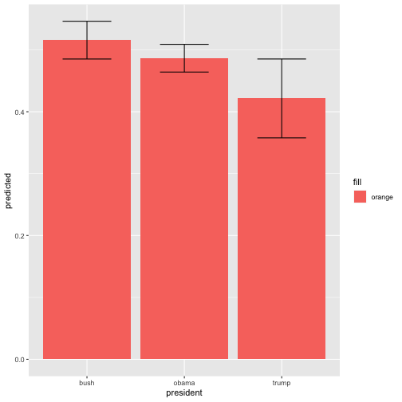

```r
ggplot(new_data) +
  geom_col(aes(x = president, y = predicted, fill = "orange")) +
  geom_errorbar(aes(x = president, ymin = lower, ymax = upper), width = 0.5)
```

### Other modeling packages

- Panel and multilevel: `plm`, `lme4`
- Spatial regression: `spdep`
- Model training: `caret`
- Ordered logit and others: `MASS`
- Lots of Bayesian tools, e.g. `tidybayes`
- So… many… models…